### Project: missing an appoinments data analysis¶

Table of Contents Introduction Data Wrangling Data cleaning Exploratory Data Analysis Conclusion

### Introduction :

```python
import pandas as pd
import numpy as np
import seaborn as sns
import matplotlib.pyplot as plt
%matplotlib inline
```

```python
# Here I will load the data and understanding and if there's any missing values or duplicates values
# Also I wll see if there's any column that I don't need it in my analysis
df = pd.read_csv('noshowappointments-kagglev2-may-2016.csv')
df.head()
```

|  | PatientId | AppointmentID | Gender | ScheduledDay | AppointmentDay | Age | Neighbourhood | Scholarship | Hipertension | Diabetes | Alcoholism | Handcap | SMS_received | No-show |
| --- | --- | --- | --- | --- | --- | --- | --- | --- | --- | --- | --- | --- | --- | --- |
| 0 | 2.987250e+13 | 5642903 | F | 2016-04-29T18:38:08Z | 2016-04-29T00:00:00Z | 62 | JARDIM DA PENHA | 0 | 1 | 0 | 0 | 0 | 0 | No |
| 1 | 5.589978e+14 | 5642503 | M | 2016-04-29T16:08:27Z | 2016-04-29T00:00:00Z | 56 | JARDIM DA PENHA | 0 | 0 | 0 | 0 | 0 | 0 | No |
| 2 | 4.262962e+12 | 5642549 | F | 2016-04-29T16:19:04Z | 2016-04-29T00:00:00Z | 62 | MATA DA PRAIA | 0 | 0 | 0 | 0 | 0 | 0 | No |
| 3 | 8.679512e+11 | 5642828 | F | 2016-04-29T17:29:31Z | 2016-04-29T00:00:00Z | 8 | PONTAL DE CAMBURI | 0 | 0 | 0 | 0 | 0 | 0 | No |
| 4 | 8.841186e+12 | 5642494 | F | 2016-04-29T16:07:23Z | 2016-04-29T00:00:00Z | 56 | JARDIM DA PENHA | 0 | 1 | 1 | 0 | 0 | 0 | No |

### Data Wrangling :

```python
df.info()
```

```
<class 'pandas.core.frame.DataFrame'>
RangeIndex: 110527 entries, 0 to 110526
Data columns (total 14 columns):
 #   Column          Non-Null Count   Dtype
---  ------          --------------   -----
 0   PatientId       110527 non-null  float64
 1   AppointmentID   110527 non-null  int64
 2   Gender          110527 non-null  object
 3   ScheduledDay    110527 non-null  object
 4   AppointmentDay  110527 non-null  object
 5   Age             110527 non-null  int64
 6   Neighbourhood   110527 non-null  object
 7   Scholarship     110527 non-null  int64
 8   Hipertension    110527 non-null  int64
 9   Diabetes        110527 non-null  int64
 10  Alcoholism      110527 non-null  int64
 11  Handcap         110527 non-null  int64
 12  SMS_received    110527 non-null  int64
 13  No-show         110527 non-null  object
dtypes: float64(1), int64(8), object(5)
memory usage: 11.8+ MB
```

No missing valuse.

```python
sum(df.duplicated())
```

```
0
```

No duplicates.

### Distribution of data

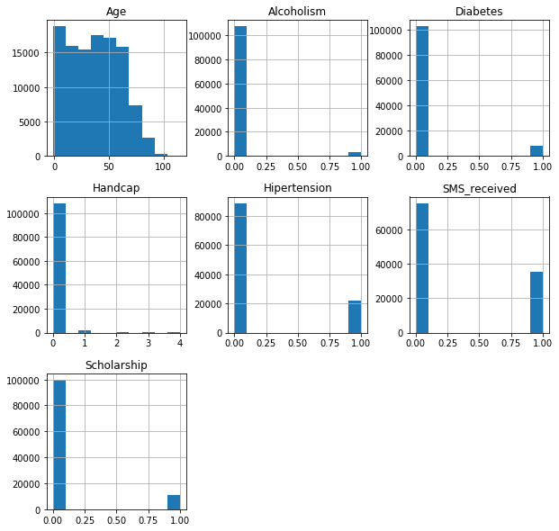

```python
df.hist(figsize=(10,10));
```

### Data cleaning:

After understanding the data and checking for cleanliness, and since there's no missing values and duplicates in the data, the only thing that I will do is drop some columns that I don't need in my analysis or it's not useful after that I will remove the (Z) Letter in scheduleDay's data. Also No_show column is confusing, so, I will change it to True if the patient comes else False.

```python
df.drop(['PatientId', 'AppointmentID', 'AppointmentDay'], axis=1, inplace=True)
df.rename(columns={'No-show':'No_show'}, inplace=True)
```

```python
df['No_show'] = df['No_show'].apply(lambda x: True if x=='No' else False)
df.drop('No_show', axis=1)
```

|  | Gender | ScheduledDay | Age | Neighbourhood | Scholarship | Hipertension | Diabetes | Alcoholism | Handcap | SMS_received |
| --- | --- | --- | --- | --- | --- | --- | --- | --- | --- | --- |
| 0 | F | 2016-04-29T18:38:08Z | 62 | JARDIM DA PENHA | 0 | 1 | 0 | 0 | 0 | 0 |
| 1 | M | 2016-04-29T16:08:27Z | 56 | JARDIM DA PENHA | 0 | 0 | 0 | 0 | 0 | 0 |
| 2 | F | 2016-04-29T16:19:04Z | 62 | MATA DA PRAIA | 0 | 0 | 0 | 0 | 0 | 0 |
| 3 | F | 2016-04-29T17:29:31Z | 8 | PONTAL DE CAMBURI | 0 | 0 | 0 | 0 | 0 | 0 |
| 4 | F | 2016-04-29T16:07:23Z | 56 | JARDIM DA PENHA | 0 | 1 | 1 | 0 | 0 | 0 |
| ... | ... | ... | ... | ... | ... | ... | ... | ... | ... | ... |
| 110522 | F | 2016-05-03T09:15:35Z | 56 | MARIA ORTIZ | 0 | 0 | 0 | 0 | 0 | 1 |
| 110523 | F | 2016-05-03T07:27:33Z | 51 | MARIA ORTIZ | 0 | 0 | 0 | 0 | 0 | 1 |
| 110524 | F | 2016-04-27T16:03:52Z | 21 | MARIA ORTIZ | 0 | 0 | 0 | 0 | 0 | 1 |
| 110525 | F | 2016-04-27T15:09:23Z | 38 | MARIA ORTIZ | 0 | 0 | 0 | 0 | 0 | 1 |
| 110526 | F | 2016-04-27T13:30:56Z | 54 | MARIA ORTIZ | 0 | 0 | 0 | 0 | 0 | 1 |

110527 rows × 10 columns

```python
df['ScheduledDay'] = df['ScheduledDay'].str.replace(r'Z', '')
df['ScheduledDay'] = pd.to_datetime(df['ScheduledDay'])
```

```python
df.head()
```

|  | Gender | ScheduledDay | Age | Neighbourhood | Scholarship | Hipertension | Diabetes | Alcoholism | Handcap | SMS_received | No_show |
| --- | --- | --- | --- | --- | --- | --- | --- | --- | --- | --- | --- |
| 0 | F | 2016-04-29 18:38:08 | 62 | JARDIM DA PENHA | 0 | 1 | 0 | 0 | 0 | 0 | True |
| 1 | M | 2016-04-29 16:08:27 | 56 | JARDIM DA PENHA | 0 | 0 | 0 | 0 | 0 | 0 | True |
| 2 | F | 2016-04-29 16:19:04 | 62 | MATA DA PRAIA | 0 | 0 | 0 | 0 | 0 | 0 | True |
| 3 | F | 2016-04-29 17:29:31 | 8 | PONTAL DE CAMBURI | 0 | 0 | 0 | 0 | 0 | 0 | True |
| 4 | F | 2016-04-29 16:07:23 | 56 | JARDIM DA PENHA | 0 | 1 | 1 | 0 | 0 | 0 | True |

```python
#Summary statstic
df.describe()
```

|  | Age | Scholarship | Hipertension | Diabetes | Alcoholism | Handcap | SMS_received |
| --- | --- | --- | --- | --- | --- | --- | --- |
| count | 110527.000000 | 110527.000000 | 110527.000000 | 110527.000000 | 110527.000000 | 110527.000000 | 110527.000000 |
| mean | 37.088874 | 0.098266 | 0.197246 | 0.071865 | 0.030400 | 0.022248 | 0.321026 |
| std | 23.110205 | 0.297675 | 0.397921 | 0.258265 | 0.171686 | 0.161543 | 0.466873 |
| min | -1.000000 | 0.000000 | 0.000000 | 0.000000 | 0.000000 | 0.000000 | 0.000000 |
| 25% | 18.000000 | 0.000000 | 0.000000 | 0.000000 | 0.000000 | 0.000000 | 0.000000 |
| 50% | 37.000000 | 0.000000 | 0.000000 | 0.000000 | 0.000000 | 0.000000 | 0.000000 |
| 75% | 55.000000 | 0.000000 | 0.000000 | 0.000000 | 0.000000 | 0.000000 | 1.000000 |
| max | 115.000000 | 1.000000 | 1.000000 | 1.000000 | 1.000000 | 4.000000 | 1.000000 |

```python
show=df.No_show == True
Noa_show= df.No_show == False
```

### Exploraions

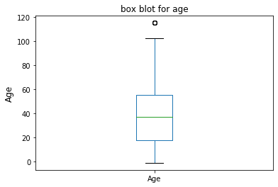

```python
df['Age'].plot(kind='box');
plt.ylabel('Age', fontsize=12)
plt.title('box blot for age')
plt.show();
```

```python
df.Gender.value_counts()
```

```
F    71840
M    38687
Name: Gender, dtype: int64
```

males almost half the females

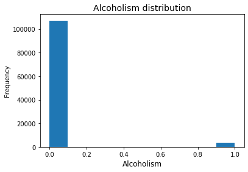

```python
# Alcoholism distribution:
df['Alcoholism'].plot(kind='hist');
plt.title('Alcoholism distribution', fontsize=14)
plt.xlabel('Alcoholism', fontsize=12)
plt.show();
```

The majority of patients are not Alcoholism.

### who're more missing the appointments between females and males?

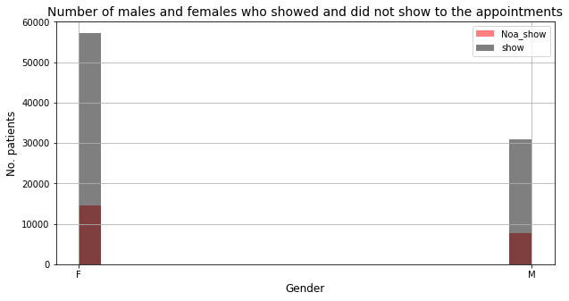

```python
df.Gender[Noa_show].hist(Alpha=0.5, bins=20, label='Noa_show', color='red', figsize=(10,5))
df.Gender[show].hist(Alpha=0.5, bins=20, label='show', color='black')
plt.xlabel('Gender', fontsize=12)
plt.ylabel('No. patients', fontsize=12)
plt.title('Number of males and females who showed and did not show to the appointments', fontsize=14)
plt.legend()
plt.show();
```

Clearly females missing more than males, but it's logically because the females almost double the males

### which top 5 neighbourhood has the most missing appointments?

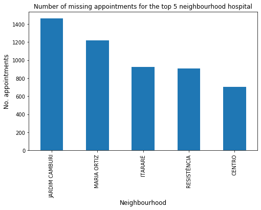

```python
df.Neighbourhood[Noa_show].value_counts()[0:5].plot(kind='bar', figsize=(8,5),)
plt.ylabel('No. appointments', fontsize=12)
plt.xlabel('Neighbourhood', fontsize=12)
plt.title("Number of missing appointments for the top 5 neighbourhood hospital", fontsize=12)
plt.show()
```

### is receiving SMS is associate with not missing the appointments ?

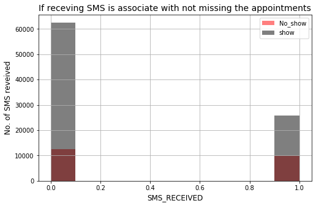

```python
df.SMS_received[Noa_show].hist(Alpha=0.5, label='No_show', color='red', figsize=(8,5))
df.SMS_received[show].hist(Alpha=0.5, label='show', color='black')
plt.xlabel('SMS_RECEIVED', fontsize=12)
plt.ylabel('No. of SMS reveived', fontsize=12)
plt.title('If receving SMS is associate with not missing the appointments',fontsize=14)
plt.legend()

plt.show();
```

it seems it doesn's associate with not missing the appointments

### conclusion

after loading and wrangling the data the clean the data, my independents variables were Gender, Age, SMS_reveived, and Alcoholism, and the dependent variable was No_show. The data was almost clean, no missing values and duplicates just needed small changes.

### Limitations and shortcomings

one of the shortcomings, they didn't note the reason of missing the appointments, the analysis will be more specific and clear if the reasons noted. The sample size wasn't a good representative of the population because the sample size is 100K and the population is almost 200 million.